# Overview

Dataset info

| Number of variables | 22 |
| --- | --- |
| Number of observations | 26137 |
| Missing cells | 0 (0.0%) |
| Duplicate rows | 0 (0.0%) |
| Total size in memory | 4.4 MiB |
| Average record size in memory | 176.0 B |

Variables types

| Numeric | 5 |
| --- | --- |
| Categorical | 6 |
| Boolean | 0 |
| Date | 0 |
| URL | 0 |
| Text (Unique) | 0 |
| Rejected | 11 |
| Unsupported | 0 |

Warnings

| `High_Wind_NE` has 5146 (19.7%) zeros | Zeros |
| --- | --- |
| `High_Wind_NW` is highly correlated with `High_Wind_NE` (ρ = 0.99999) | Rejected |
| `High_Wind_SE` is highly correlated with `High_Wind_NW` (ρ = 0.99999) | Rejected |
| `High_Wind_SW` is highly correlated with `High_Wind_SE` (ρ = 0.99999) | Rejected |
| `ID` has a high cardinality: 1050 distinct values | Warning |
| `Latitude` has a high cardinality: 371 distinct values | Warning |
| `Longitude` has a high cardinality: 1190 distinct values | Warning |
| `Low_Wind_NE` is highly correlated with `High_Wind_SW` (ρ = 0.99882) | Rejected |
| `Low_Wind_NW` is highly correlated with `Low_Wind_NE` (ρ = 0.99961) | Rejected |
| `Low_Wind_SE` is highly correlated with `Low_Wind_NW` (ρ = 0.99936) | Rejected |
| `Low_Wind_SW` is highly correlated with `Low_Wind_SE` (ρ = 0.99974) | Rejected |
| `Moderate_Wind_NE` is highly correlated with `Low_Wind_SW` (ρ = 0.99966) | Rejected |
| `Moderate_Wind_NW` is highly correlated with `Moderate_Wind_NE` (ρ = 0.99997) | Rejected |
| `Moderate_Wind_SE` is highly correlated with `Moderate_Wind_NW` (ρ = 0.99995) | Rejected |
| `Moderate_Wind_SW` is highly correlated with `Moderate_Wind_SE` (ρ = 0.99996) | Rejected |
| `Name` has a high cardinality: 267 distinct values | Warning |
| `Time` has 6632 (25.4%) zeros | Zeros |

# Variables

Date  
Numeric

| Distinct count | 5231 |
| --- | --- |
| Unique (%) | 20.0% |
| Missing (%) | 0.0% |
| Missing (n) | 0 |
| Infinite (%) | 0.0% |
| Infinite (n) | 0 |

| Mean | 1.9889e+07 |
| --- | --- |
| Minimum | 1.9491e+07 |
| Maximum | 2.0151e+07 |
| Zeros (%) | 0.0% |

[figure not shown]

Toggle details

**Statistics**

Quantile statistics

| Minimum | 1.9491e+07 |
| --- | --- |
| 5-th percentile | 1.9581e+07 |
| Q1 | 1.9761e+07 |
| Median | 1.9901e+07 |
| Q3 | 2.0031e+07 |
| 95-th percentile | 2.0141e+07 |
| Maximum | 2.0151e+07 |
| Range | 6.6052e+05 |
| Interquartile range | 2.701e+05 |

Descriptive statistics

| Standard deviation | 1.6885e+05 |
| --- | --- |
| Coef of variation | 0.0084894 |
| Kurtosis | -0.7836 |
| Mean | 1.9889e+07 |
| MAD | 1.4034e+05 |
| Skewness | -0.29352 |
| Sum | 5.1984e+11 |
| Variance | 2.8509e+10 |
| Memory size | 204.3 KiB |

**Histogram**

[figure not shown]

**Common Values**

| Value | Count | Frequency (%) |  |
| --- | --- | --- | --- |
| 1.9741e+07 | 22 | < 0.1% |  |
| 1.9741e+07 | 20 | < 0.1% |  |
| 1.9741e+07 | 20 | < 0.1% |  |
| 1.9941e+07 | 20 | < 0.1% |  |
| 1.9741e+07 | 20 | < 0.1% |  |
| 1.9941e+07 | 20 | < 0.1% |  |
| 2.0091e+07 | 20 | < 0.1% |  |
| 1.9741e+07 | 19 | < 0.1% |  |
| 1.9941e+07 | 18 | < 0.1% |  |
| 2.0091e+07 | 17 | < 0.1% |  |
| Other values (5221) | 25941 | > 99.9% |  |

**Extreme Values**

Minimum 5 values

| Value | Count | Frequency (%) |  |
| --- | --- | --- | --- |
| 1.9491e+07 | 4 | < 0.1% |  |
| 1.9491e+07 | 3 | < 0.1% |  |
| 1.9491e+07 | 2 | < 0.1% |  |
| 1.9491e+07 | 4 | < 0.1% |  |
| 1.9491e+07 | 4 | < 0.1% |  |

Maximum 5 values

| Value | Count | Frequency (%) |  |
| --- | --- | --- | --- |
| 2.0151e+07 | 3 | < 0.1% |  |
| 2.0151e+07 | 4 | < 0.1% |  |
| 2.0151e+07 | 4 | < 0.1% |  |
| 2.0151e+07 | 6 | < 0.1% |  |
| 2.0151e+07 | 8 | < 0.1% |  |

Event  
Categorical

| Distinct count | 5 |
| --- | --- |
| Unique (%) | < 0.1% |
| Missing (%) | 0.0% |
| Missing (n) | 0 |

|  | 26035 |
| --- | --- |
| L | 90 |
| I | 6 |
| Other values (2) | 6 |

Toggle details

**Frequency**

| Value | Count | Frequency (%) |  |
| --- | --- | --- | --- |
|  | 26035 | > 99.9% |  |
| L | 90 | < 0.1% |  |
| I | 6 | < 0.1% |  |
| S | 3 | < 0.1% |  |
| T | 3 | < 0.1% |  |

**Composition**

| Max length | 2 |
| --- | --- |
| Mean length | 2 |
| Min length | 2 |
| Contains chars | True |
| Contains digits | False |
| Contains spaces | True |
| Contains non-words | True |

High_Wind_NE  
Numeric

| Distinct count | 19 |
| --- | --- |
| Unique (%) | < 0.1% |
| Missing (%) | 0.0% |
| Missing (n) | 0 |
| Infinite (%) | 0.0% |
| Infinite (n) | 0 |

| Mean | -753.58 |
| --- | --- |
| Minimum | -999 |
| Maximum | 100 |
| Zeros (%) | 19.7% |

[figure not shown]

Toggle details

**Statistics**

Quantile statistics

| Minimum | -999 |
| --- | --- |
| 5-th percentile | -999 |
| Q1 | -999 |
| Median | -999 |
| Q3 | -999 |
| 95-th percentile | 0 |
| Maximum | 100 |
| Range | 1099 |
| Interquartile range | 0 |

Descriptive statistics

| Standard deviation | 431.61 |
| --- | --- |
| Coef of variation | -0.57274 |
| Kurtosis | -0.58154 |
| Mean | -753.58 |
| MAD | 370.89 |
| Skewness | 1.1905 |
| Sum | -1.9696e+07 |
| Variance | 1.8628e+05 |
| Memory size | 204.3 KiB |

**Histogram**

[figure not shown]

**Common Values**

| Value | Count | Frequency (%) |  |
| --- | --- | --- | --- |
| -999 | 19750 | 75.6% |  |
| 0 | 5146 | 19.7% |  |
| 20 | 344 | < 0.1% |  |
| 30 | 217 | < 0.1% |  |
| 15 | 177 | < 0.1% |  |
| 25 | 147 | < 0.1% |  |
| 35 | 82 | < 0.1% |  |
| 40 | 82 | < 0.1% |  |
| 50 | 61 | < 0.1% |  |
| 10 | 54 | < 0.1% |  |
| Other values (9) | 77 | < 0.1% |  |

**Extreme Values**

Minimum 5 values

| Value | Count | Frequency (%) |  |
| --- | --- | --- | --- |
| -999 | 19750 | 75.6% |  |
| 0 | 5146 | 19.7% |  |
| 5 | 1 | < 0.1% |  |
| 10 | 54 | < 0.1% |  |
| 15 | 177 | < 0.1% |  |

Maximum 5 values

| Value | Count | Frequency (%) |  |
| --- | --- | --- | --- |
| 100 | 1 | < 0.1% |  |
| 90 | 1 | < 0.1% |  |
| 75 | 3 | < 0.1% |  |
| 70 | 7 | < 0.1% |  |
| 65 | 11 | < 0.1% |  |

High_Wind_NW  
Highly correlated

*This variable is highly correlated with `High_Wind_NE` and should be ignored for analysis*

| Correlation | 0.99999 |
| --- | --- |

High_Wind_SE  
Highly correlated

*This variable is highly correlated with `High_Wind_NW` and should be ignored for analysis*

| Correlation | 0.99999 |
| --- | --- |

High_Wind_SW  
Highly correlated

*This variable is highly correlated with `High_Wind_SE` and should be ignored for analysis*

| Correlation | 0.99999 |
| --- | --- |

ID  
Categorical

| Distinct count | 1050 |
| --- | --- |
| Unique (%) | < 0.1% |
| Missing (%) | 0.0% |
| Missing (n) | 0 |

| EP101994 | 121 |
| --- | --- |
| EP091997 | 99 |
| EP221992 | 98 |
| Other values (1047) | 25819 |

Toggle details

**Frequency**

| Value | Count | Frequency (%) |  |
| --- | --- | --- | --- |
| EP101994 | 121 | < 0.1% |  |
| EP091997 | 99 | < 0.1% |  |
| EP221992 | 98 | < 0.1% |  |
| CP051997 | 96 | < 0.1% |  |
| EP072014 | 87 | < 0.1% |  |
| CP011993 | 83 | < 0.1% |  |
| CP012006 | 83 | < 0.1% |  |
| EP021984 | 82 | < 0.1% |  |
| CP021997 | 81 | < 0.1% |  |
| EP061978 | 80 | < 0.1% |  |
| Other values (1040) | 25227 | > 99.9% |  |

**Composition**

| Max length | 8 |
| --- | --- |
| Mean length | 8 |
| Min length | 8 |
| Contains chars | True |
| Contains digits | True |
| Contains spaces | False |
| Contains non-words | False |

Latitude  
Categorical

| Distinct count | 371 |
| --- | --- |
| Unique (%) | < 0.1% |
| Missing (%) | 0.0% |
| Missing (n) | 0 |

| 16.0N | 337 |
| --- | --- |
| 17.0N | 317 |
| 15.0N | 306 |
| Other values (368) | 25177 |

Toggle details

**Frequency**

| Value | Count | Frequency (%) |  |
| --- | --- | --- | --- |
| 16.0N | 337 | < 0.1% |  |
| 17.0N | 317 | < 0.1% |  |
| 15.0N | 306 | < 0.1% |  |
| 14.0N | 287 | < 0.1% |  |
| 15.5N | 287 | < 0.1% |  |
| 16.7N | 280 | < 0.1% |  |
| 14.6N | 274 | < 0.1% |  |
| 17.5N | 273 | < 0.1% |  |
| 14.8N | 270 | < 0.1% |  |
| 16.3N | 270 | < 0.1% |  |
| Other values (361) | 23236 | 88.9% |  |

**Composition**

| Max length | 5 |
| --- | --- |
| Mean length | 4.9802 |
| Min length | 4 |
| Contains chars | True |
| Contains digits | True |
| Contains spaces | False |
| Contains non-words | True |

Longitude  
Categorical

| Distinct count | 1190 |
| --- | --- |
| Unique (%) | < 0.1% |
| Missing (%) | 0.0% |
| Missing (n) | 0 |

| 110.0W | 135 |
| --- | --- |
| 109.0W | 124 |
| 111.0W | 122 |
| Other values (1187) | 25756 |

Toggle details

**Frequency**

| Value | Count | Frequency (%) |  |
| --- | --- | --- | --- |
| 110.0W | 135 | < 0.1% |  |
| 109.0W | 124 | < 0.1% |  |
| 111.0W | 122 | < 0.1% |  |
| 112.0W | 108 | < 0.1% |  |
| 109.5W | 105 | < 0.1% |  |
| 112.5W | 103 | < 0.1% |  |
| 108.8W | 102 | < 0.1% |  |
| 108.6W | 101 | < 0.1% |  |
| 108.0W | 101 | < 0.1% |  |
| 112.8W | 98 | < 0.1% |  |
| Other values (1180) | 25038 | > 99.9% |  |

**Composition**

| Max length | 6 |
| --- | --- |
| Mean length | 5.9444 |
| Min length | 5 |
| Contains chars | True |
| Contains digits | True |
| Contains spaces | False |
| Contains non-words | True |

Low_Wind_NE  
Highly correlated

*This variable is highly correlated with `High_Wind_SW` and should be ignored for analysis*

| Correlation | 0.99882 |
| --- | --- |

Low_Wind_NW  
Highly correlated

*This variable is highly correlated with `Low_Wind_NE` and should be ignored for analysis*

| Correlation | 0.99961 |
| --- | --- |

Low_Wind_SE  
Highly correlated

*This variable is highly correlated with `Low_Wind_NW` and should be ignored for analysis*

| Correlation | 0.99936 |
| --- | --- |

Low_Wind_SW  
Highly correlated

*This variable is highly correlated with `Low_Wind_SE` and should be ignored for analysis*

| Correlation | 0.99974 |
| --- | --- |

Maximum_Wind  
Numeric

| Distinct count | 37 |
| --- | --- |
| Unique (%) | < 0.1% |
| Missing (%) | 0.0% |
| Missing (n) | 0 |
| Infinite (%) | 0.0% |
| Infinite (n) | 0 |

| Mean | 48.949 |
| --- | --- |
| Minimum | 10 |
| Maximum | 185 |
| Zeros (%) | 0.0% |

[figure not shown]

Toggle details

**Statistics**

Quantile statistics

| Minimum | 10 |
| --- | --- |
| 5-th percentile | 25 |
| Q1 | 30 |
| Median | 45 |
| Q3 | 65 |
| 95-th percentile | 100 |
| Maximum | 185 |
| Range | 175 |
| Interquartile range | 35 |

Descriptive statistics

| Standard deviation | 25.334 |
| --- | --- |
| Coef of variation | 0.51756 |
| Kurtosis | 0.90964 |
| Mean | 48.949 |
| MAD | 20.182 |
| Skewness | 1.1825 |
| Sum | 1.2794e+06 |
| Variance | 641.83 |
| Memory size | 204.3 KiB |

**Histogram**

[figure not shown]

**Common Values**

| Value | Count | Frequency (%) |  |
| --- | --- | --- | --- |
| 25 | 4310 | 16.5% |  |
| 30 | 3807 | 14.6% |  |
| 45 | 3694 | 14.1% |  |
| 35 | 2136 | 8.2% |  |
| 75 | 1732 | 6.6% |  |
| 40 | 1432 | 5.5% |  |
| 50 | 1060 | < 0.1% |  |
| 55 | 1060 | < 0.1% |  |
| 65 | 967 | < 0.1% |  |
| 20 | 939 | < 0.1% |  |
| Other values (27) | 5000 | 19.1% |  |

**Extreme Values**

Minimum 5 values

| Value | Count | Frequency (%) |  |
| --- | --- | --- | --- |
| 10 | 7 | < 0.1% |  |
| 15 | 110 | < 0.1% |  |
| 20 | 939 | < 0.1% |  |
| 25 | 4310 | 16.5% |  |
| 30 | 3807 | 14.6% |  |

Maximum 5 values

| Value | Count | Frequency (%) |  |
| --- | --- | --- | --- |
| 185 | 1 | < 0.1% |  |
| 180 | 2 | < 0.1% |  |
| 160 | 2 | < 0.1% |  |
| 155 | 5 | < 0.1% |  |
| 150 | 7 | < 0.1% |  |

Minimum_Pressure  
Numeric

| Distinct count | 118 |
| --- | --- |
| Unique (%) | < 0.1% |
| Missing (%) | 0.0% |
| Missing (n) | 0 |
| Infinite (%) | 0.0% |
| Infinite (n) | 0 |

| Mean | 18.176 |
| --- | --- |
| Minimum | -999 |
| Maximum | 1021 |
| Zeros (%) | 0.0% |

[figure not shown]

Toggle details

**Statistics**

Quantile statistics

| Minimum | -999 |
| --- | --- |
| 5-th percentile | -999 |
| Q1 | -999 |
| Median | 941 |
| Q3 | 1002 |
| 95-th percentile | 1009 |
| Maximum | 1021 |
| Range | 2020 |
| Interquartile range | 2001 |

Descriptive statistics

| Standard deviation | 996.9 |
| --- | --- |
| Coef of variation | 54.846 |
| Kurtosis | -1.9979 |
| Mean | 18.176 |
| MAD | 996.59 |
| Skewness | -0.039989 |
| Sum | 4.7507e+05 |
| Variance | 9.938e+05 |
| Memory size | 204.3 KiB |

**Histogram**

[figure not shown]

**Common Values**

| Value | Count | Frequency (%) |  |
| --- | --- | --- | --- |
| -999 | 12804 | 49.0% |  |
| 1009 | 985 | < 0.1% |  |
| 1005 | 900 | < 0.1% |  |
| 1008 | 849 | < 0.1% |  |
| 1007 | 842 | < 0.1% |  |
| 1006 | 805 | < 0.1% |  |
| 1000 | 713 | < 0.1% |  |
| 1010 | 594 | < 0.1% |  |
| 1004 | 543 | < 0.1% |  |
| 1002 | 523 | < 0.1% |  |
| Other values (108) | 6579 | 25.2% |  |

**Extreme Values**

Minimum 5 values

| Value | Count | Frequency (%) |  |
| --- | --- | --- | --- |
| -999 | 12804 | 49.0% |  |
| 872 | 1 | < 0.1% |  |
| 878 | 1 | < 0.1% |  |
| 886 | 1 | < 0.1% |  |
| 900 | 4 | < 0.1% |  |

Maximum 5 values

| Value | Count | Frequency (%) |  |
| --- | --- | --- | --- |
| 1021 | 6 | < 0.1% |  |
| 1020 | 1 | < 0.1% |  |
| 1019 | 1 | < 0.1% |  |
| 1018 | 2 | < 0.1% |  |
| 1017 | 3 | < 0.1% |  |

Moderate_Wind_NE  
Highly correlated

*This variable is highly correlated with `Low_Wind_SW` and should be ignored for analysis*

| Correlation | 0.99966 |
| --- | --- |

Moderate_Wind_NW  
Highly correlated

*This variable is highly correlated with `Moderate_Wind_NE` and should be ignored for analysis*

| Correlation | 0.99997 |
| --- | --- |

Moderate_Wind_SE  
Highly correlated

*This variable is highly correlated with `Moderate_Wind_NW` and should be ignored for analysis*

| Correlation | 0.99995 |
| --- | --- |

Moderate_Wind_SW  
Highly correlated

*This variable is highly correlated with `Moderate_Wind_SE` and should be ignored for analysis*

| Correlation | 0.99996 |
| --- | --- |

Name  
Categorical

| Distinct count | 267 |
| --- | --- |
| Unique (%) | < 0.1% |
| Missing (%) | 0.0% |
| Missing (n) | 0 |

| UNNAMED | 2180 |
| --- | --- |
| FERNANDA | 318 |
| JOHN | 295 |
| Other values (264) | 23344 |

Toggle details

**Frequency**

| Value | Count | Frequency (%) |  |
| --- | --- | --- | --- |
| UNNAMED | 2180 | 8.3% |  |
| FERNANDA | 318 | < 0.1% |  |
| JOHN | 295 | < 0.1% |  |
| ESTELLE | 293 | < 0.1% |  |
| DANIEL | 292 | < 0.1% |  |
| GUILLERMO | 285 | < 0.1% |  |
| HILARY | 277 | < 0.1% |  |
| CARLOTTA | 266 | < 0.1% |  |
| GENEVIEVE | 264 | < 0.1% |  |
| BLANCA | 258 | < 0.1% |  |
| Other values (257) | 21409 | 81.9% |  |

**Composition**

| Max length | 19 |
| --- | --- |
| Mean length | 18.989 |
| Min length | 6 |
| Contains chars | True |
| Contains digits | True |
| Contains spaces | True |
| Contains non-words | True |

Status  
Categorical

| Distinct count | 12 |
| --- | --- |
| Unique (%) | < 0.1% |
| Missing (%) | 0.0% |
| Missing (n) | 0 |

| TS | 10076 |
| --- | --- |
| TD | 6965 |
| HU | 6765 |
| Other values (9) | 2331 |

Toggle details

**Frequency**

| Value | Count | Frequency (%) |  |
| --- | --- | --- | --- |
| TS | 10076 | 38.6% |  |
| TD | 6965 | 26.6% |  |
| HU | 6765 | 25.9% |  |
| LO | 1828 | 7.0% |  |
| DB | 217 | < 0.1% |  |
| ET | 152 | < 0.1% |  |
| EX | 110 | < 0.1% |  |
| SS | 7 | < 0.1% |  |
| PT | 6 | < 0.1% |  |
| ST | 6 | < 0.1% |  |
| Other values (2) | 5 | < 0.1% |  |

**Composition**

| Max length | 4 |
| --- | --- |
| Mean length | 3 |
| Min length | 3 |
| Contains chars | True |
| Contains digits | False |
| Contains spaces | True |
| Contains non-words | True |

Time  
Numeric

| Distinct count | 36 |
| --- | --- |
| Unique (%) | < 0.1% |
| Missing (%) | 0.0% |
| Missing (n) | 0 |
| Infinite (%) | 0.0% |
| Infinite (n) | 0 |

| Mean | 896.05 |
| --- | --- |
| Minimum | 0 |
| Maximum | 2300 |
| Zeros (%) | 25.4% |

[figure not shown]

Toggle details

**Statistics**

Quantile statistics

| Minimum | 0 |
| --- | --- |
| 5-th percentile | 0 |
| Q1 | 0 |
| Median | 600 |
| Q3 | 1200 |
| 95-th percentile | 1800 |
| Maximum | 2300 |
| Range | 2300 |
| Interquartile range | 1200 |

Descriptive statistics

| Standard deviation | 672.01 |
| --- | --- |
| Coef of variation | 0.74997 |
| Kurtosis | -1.3613 |
| Mean | 896.05 |
| MAD | 601.1 |
| Skewness | 0.0055825 |
| Sum | 2.342e+07 |
| Variance | 4.5159e+05 |
| Memory size | 204.3 KiB |

**Histogram**

[figure not shown]

**Common Values**

| Value | Count | Frequency (%) |  |
| --- | --- | --- | --- |
| 0 | 6632 | 25.4% |  |
| 1200 | 6559 | 25.1% |  |
| 1800 | 6442 | 24.6% |  |
| 600 | 6426 | 24.6% |  |
| 2100 | 8 | < 0.1% |  |
| 900 | 6 | < 0.1% |  |
| 2000 | 5 | < 0.1% |  |
| 1000 | 4 | < 0.1% |  |
| 500 | 4 | < 0.1% |  |
| 1700 | 4 | < 0.1% |  |
| Other values (26) | 47 | < 0.1% |  |

**Extreme Values**

Minimum 5 values

| Value | Count | Frequency (%) |  |
| --- | --- | --- | --- |
| 0 | 6632 | 25.4% |  |
| 100 | 3 | < 0.1% |  |
| 200 | 1 | < 0.1% |  |
| 300 | 3 | < 0.1% |  |
| 400 | 4 | < 0.1% |  |

Maximum 5 values

| Value | Count | Frequency (%) |  |
| --- | --- | --- | --- |
| 2300 | 2 | < 0.1% |  |
| 2230 | 1 | < 0.1% |  |
| 2200 | 1 | < 0.1% |  |
| 2100 | 8 | < 0.1% |  |
| 2030 | 2 | < 0.1% |  |

# Correlations

**Pearson**

[figure not shown]

**Spearman**

[figure not shown]

**Kendall**

[figure not shown]

**Phik**

[figure not shown]

**Recoded**

[figure not shown]

# Missing values

## Matrix

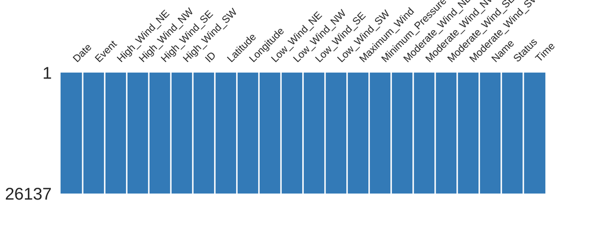

## Count

[figure not shown]

# Sample

## First rows

|  | Date | Event | High_Wind_NE | High_Wind_NW | High_Wind_SE | High_Wind_SW | ID | Latitude | Longitude | Low_Wind_NE | Low_Wind_NW | Low_Wind_SE | Low_Wind_SW | Maximum_Wind | Minimum_Pressure | Moderate_Wind_NE | Moderate_Wind_NW | Moderate_Wind_SE | Moderate_Wind_SW | Name | Status | Time |
| --- | --- | --- | --- | --- | --- | --- | --- | --- | --- | --- | --- | --- | --- | --- | --- | --- | --- | --- | --- | --- | --- | --- |
| 0 | 19490611 |  | -999 | -999 | -999 | -999 | EP011949 | 20.2N | 106.3W | -999 | -999 | -999 | -999 | 45 | -999 | -999 | -999 | -999 | -999 | UNNAMED | TS | 0 |
| 1 | 19490611 |  | -999 | -999 | -999 | -999 | EP011949 | 20.2N | 106.4W | -999 | -999 | -999 | -999 | 45 | -999 | -999 | -999 | -999 | -999 | UNNAMED | TS | 600 |
| 2 | 19490611 |  | -999 | -999 | -999 | -999 | EP011949 | 20.2N | 106.7W | -999 | -999 | -999 | -999 | 45 | -999 | -999 | -999 | -999 | -999 | UNNAMED | TS | 1200 |
| 3 | 19490611 |  | -999 | -999 | -999 | -999 | EP011949 | 20.3N | 107.7W | -999 | -999 | -999 | -999 | 45 | -999 | -999 | -999 | -999 | -999 | UNNAMED | TS | 1800 |
| 4 | 19490612 |  | -999 | -999 | -999 | -999 | EP011949 | 20.4N | 108.6W | -999 | -999 | -999 | -999 | 45 | -999 | -999 | -999 | -999 | -999 | UNNAMED | TS | 0 |
| 5 | 19490612 |  | -999 | -999 | -999 | -999 | EP011949 | 20.5N | 109.4W | -999 | -999 | -999 | -999 | 45 | -999 | -999 | -999 | -999 | -999 | UNNAMED | TS | 600 |
| 6 | 19490612 |  | -999 | -999 | -999 | -999 | EP011949 | 20.6N | 110.2W | -999 | -999 | -999 | -999 | 45 | -999 | -999 | -999 | -999 | -999 | UNNAMED | TS | 1200 |
| 7 | 19490617 |  | -999 | -999 | -999 | -999 | EP021949 | 14.1N | 107.0W | -999 | -999 | -999 | -999 | 45 | -999 | -999 | -999 | -999 | -999 | UNNAMED | TS | 1200 |
| 8 | 19490617 |  | -999 | -999 | -999 | -999 | EP021949 | 14.6N | 107.7W | -999 | -999 | -999 | -999 | 45 | -999 | -999 | -999 | -999 | -999 | UNNAMED | TS | 1800 |
| 9 | 19490618 |  | -999 | -999 | -999 | -999 | EP021949 | 15.0N | 108.4W | -999 | -999 | -999 | -999 | 45 | -999 | -999 | -999 | -999 | -999 | UNNAMED | TS | 0 |

## Last rows

|  | Date | Event | High_Wind_NE | High_Wind_NW | High_Wind_SE | High_Wind_SW | ID | Latitude | Longitude | Low_Wind_NE | Low_Wind_NW | Low_Wind_SE | Low_Wind_SW | Maximum_Wind | Minimum_Pressure | Moderate_Wind_NE | Moderate_Wind_NW | Moderate_Wind_SE | Moderate_Wind_SW | Name | Status | Time |
| --- | --- | --- | --- | --- | --- | --- | --- | --- | --- | --- | --- | --- | --- | --- | --- | --- | --- | --- | --- | --- | --- | --- |
| 26127 | 20151127 |  | 30 | 20 | 25 | 15 | EP222015 | 18.5N | 109.3W | 140 | 90 | 120 | 60 | 95 | 963 | 60 | 30 | 40 | 30 | SANDRA | HU | 600 |
| 26128 | 20151127 |  | 30 | 20 | 25 | 15 | EP222015 | 19.3N | 108.8W | 140 | 70 | 120 | 50 | 85 | 970 | 60 | 30 | 40 | 30 | SANDRA | HU | 1200 |
| 26129 | 20151127 |  | 35 | 20 | 25 | 10 | EP222015 | 20.0N | 108.2W | 130 | 60 | 110 | 40 | 75 | 978 | 60 | 30 | 40 | 20 | SANDRA | HU | 1800 |
| 26130 | 20151128 |  | 0 | 0 | 0 | 0 | EP222015 | 20.7N | 108.8W | 120 | 60 | 110 | 40 | 60 | 987 | 50 | 30 | 40 | 0 | SANDRA | TS | 0 |
| 26131 | 20151128 |  | 0 | 0 | 0 | 0 | EP222015 | 21.2N | 109.1W | 100 | 0 | 60 | 0 | 40 | 994 | 0 | 0 | 0 | 0 | SANDRA | LO | 600 |
| 26132 | 20151128 |  | 0 | 0 | 0 | 0 | EP222015 | 21.7N | 109.0W | 60 | 0 | 0 | 0 | 35 | 1002 | 0 | 0 | 0 | 0 | SANDRA | LO | 1200 |
| 26133 | 20151128 |  | 0 | 0 | 0 | 0 | EP222015 | 22.4N | 108.7W | 0 | 0 | 0 | 0 | 30 | 1007 | 0 | 0 | 0 | 0 | SANDRA | LO | 1800 |
| 26134 | 20151129 |  | 0 | 0 | 0 | 0 | EP222015 | 23.1N | 108.3W | 0 | 0 | 0 | 0 | 30 | 1008 | 0 | 0 | 0 | 0 | SANDRA | LO | 0 |
| 26135 | 20151129 |  | 0 | 0 | 0 | 0 | EP222015 | 23.5N | 107.9W | 0 | 0 | 0 | 0 | 25 | 1009 | 0 | 0 | 0 | 0 | SANDRA | LO | 600 |
| 26136 | 20151129 |  | 0 | 0 | 0 | 0 | EP222015 | 24.2N | 107.7W | 0 | 0 | 0 | 0 | 20 | 1010 | 0 | 0 | 0 | 0 | SANDRA | LO | 1200 |